# 网络中心度

邹俊杰

2016年12月8日

# 1 图的表示

- 邻接连表
- 邻接矩阵

## 1.1 igraph包的应用

```r
library(igraph)
```

创建graph并绘图

```r
#graph_from_literal()
#To create small graphs with a given structure probably the graph_from_literal function is easiest.
graph_from_literal()
```

```
## IGRAPH U--- 0 0 --
## + edges:
```

```r
graph_from_literal(A-B)
```

```
## IGRAPH UN-- 2 1 --
## + attr: name (v/c)
## + edge (vertex names):
## [1] A--B
```

```r
graph_from_literal( A-----B )
```

```
## IGRAPH UN-- 2 1 --
## + attr: name (v/c)
## + edge (vertex names):
## [1] A--B
```

```r
graph_from_literal( A--B, C--D, E--F, G--H, I, J, K )
```

```
## IGRAPH UN-- 11 4 --
## + attr: name (v/c)
## + edges (vertex names):
## [1] A--B C--D E--F G--H
```

```r
graph_from_literal( A +- B -- C )
```

```
## IGRAPH DN-- 3 1 --
## + attr: name (v/c)
## + edge (vertex names):
## [1] B->A
```

```r
graph_from_literal( "this is" +- "a silly" -+ "graph here" )
```

```
## IGRAPH DN-- 3 2 --
## + attr: name (v/c)
## + edges (vertex names):
## [1] a silly->this is    a silly->graph here
```

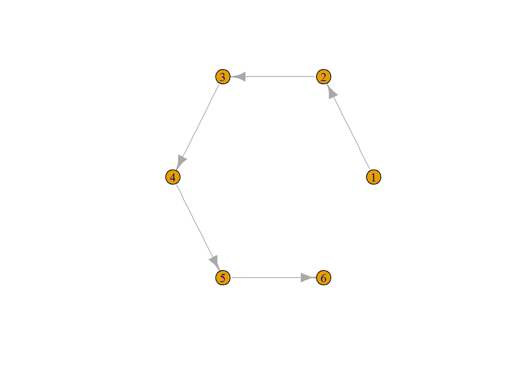

```r
#make_graph(edges, ..., n = max(edges), isolates = NULL, directed = TRUE, dir = directed, simplify = TRUE)
# 可以使用最基本的make_graph函数，用向量作为参数来创建图形，之后用plot绘制出结果
g1 <- make_graph( c(1, 2, 2, 3, 3, 4, 4,5,5, 6),directed = T)
plot(g1,layout=layout.circle(g1))
```

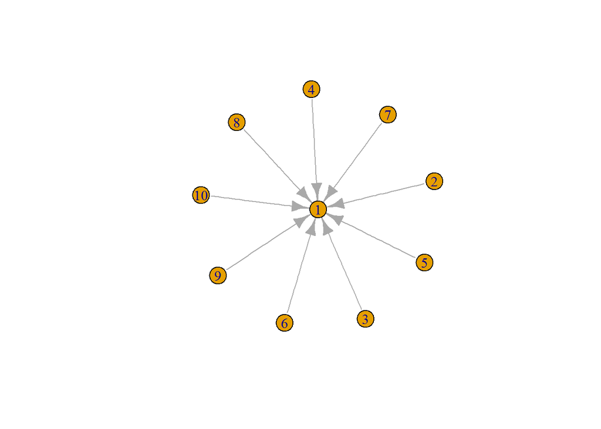

```r
#make_star()
# 也可以画出一些特殊结构的图形，例如下面的星形图
g2 <- make_star(10, mode = "in")
plot(g2,layout=layout.fruchterman.reingold(g2))
```

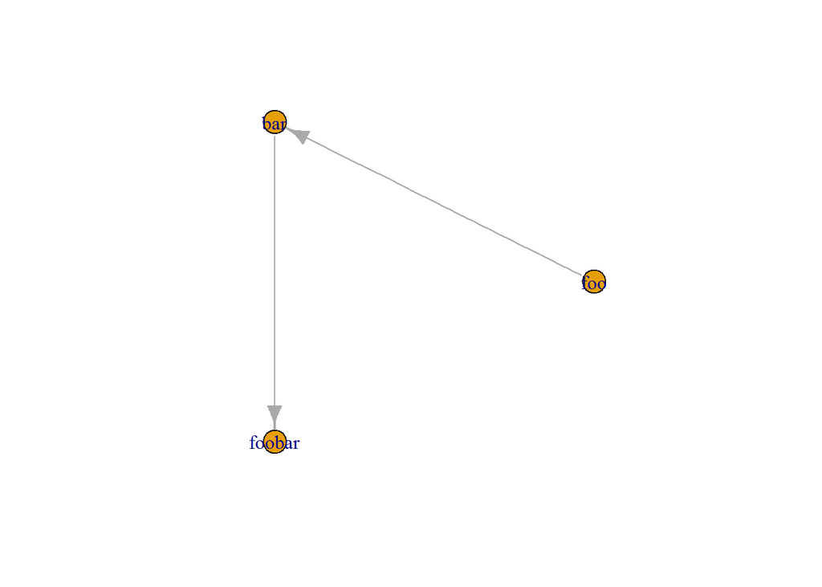

```r
#graph_from_edgelist(el, directed = TRUE)
#graph_from_edgelist creates a graph from an edge list. Its argument is a two-column matrix, each row defines one edge.
el <- matrix( c("foo", "bar", "bar", "foobar"), nc = 2, byrow = TRUE)
g2<- graph_from_edgelist(el)
plot(g2,layout=layout.circle(g2))
```

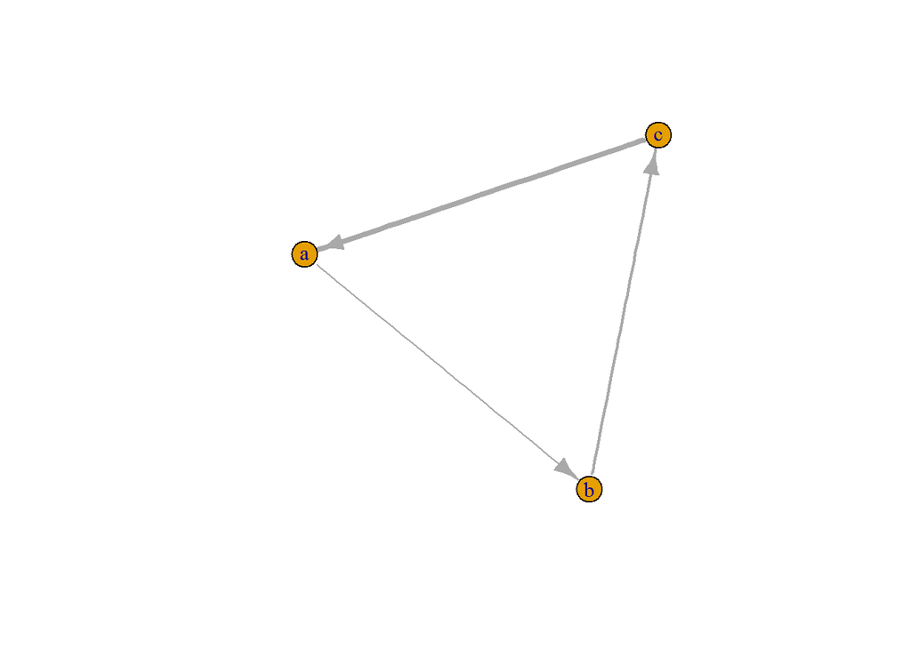

```r
#graph_from_data_frame(d, directed = TRUE, vertices = NULL)
#as_data_frame(x, what = c("edges", "vertices", "both"))
#This function creates an igraph graph from one or two data frames containing the (symbolic) edge list and edge/vertex attributes.
d = data.frame(p1     = c('a', 'b', 'c'),
               p2     = c('b', 'c', 'a'),
               weight = c(1, 2, 4))
g = graph.data.frame(d, directed = TRUE)
plot(g, edge.width = E(g)$weight)
```

## 1.2 42部门投入产出表

顶点深度反应顶点中心度

连线粗细反应部门间的联系大小

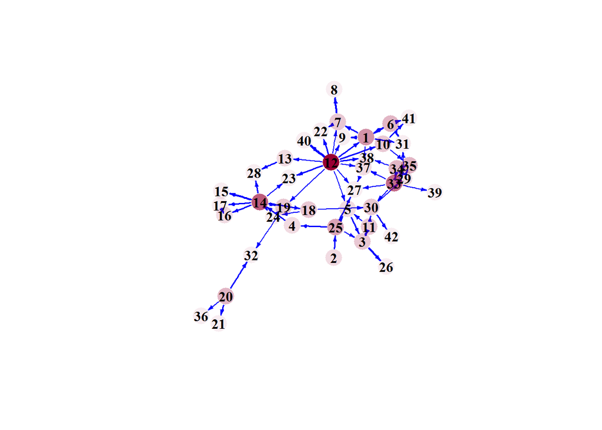

```r
t=read.csv("42部门投入产出表.csv",header=T,stringsAsFactors = F)[,-1]
X=sapply(t,sum)

#求直接消耗系数a
a=matrix(nrow = 42,ncol = 42)
for(i in 1:42){
  for(j in 1:42){
    a[i,j]=t[i,j]/X[j]
  }
}

#转换成  中间投入-中间使用-直接消耗系数  数据框
d=data.frame(stringsAsFactors = F)
for(i in 1:42){
  p1=rep(i,42)
  p2=c(1:42)
  weight=a[i,]
  temp=data.frame(p1,p2,weight)
  d=rbind(d,temp)
}

#筛选直接消耗系数大于0.1的行，并删掉中间投入与中间使用相同的行
d1=d[(d$weight>0.1)&(d$p1!=d$p2),]

#画图
g = graph.data.frame(d1, directed = T)

deg=degree(g,mode = "out")+1 #根据顶点中心度大小生成调节参数
weight=(d1$weight)^0.35*3

#方法一
set.seed("1234")#设置随机数起点。保证plot出一样的图
V(g)$color= rgb(0.6,0,0.2,deg/max(deg)) #根据顶点度大小设置颜色深浅
V(g)$frame.color = NA
V(g)$label.color='black'
V(g)$label.font=2
E(g)$width=weight #根据边的权重设置边粗细
E(g)$color='blue'
E(g)$arrow.size=0.3
plot(g)
```

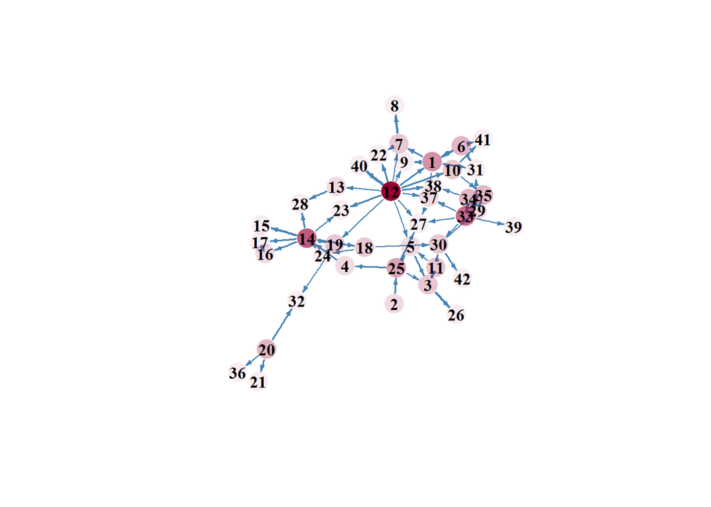

```r
#方法二
set.seed("1234")
plot(g, vertex.color= rgb(0.6,0,0.2,deg/max(deg)), vertex.frame.color = NA,
     vertex.label.color='black', vertex.label.font=2, edge.width=weight,
     edge.color='steelblue', edge.arrow.size=0.3)
```

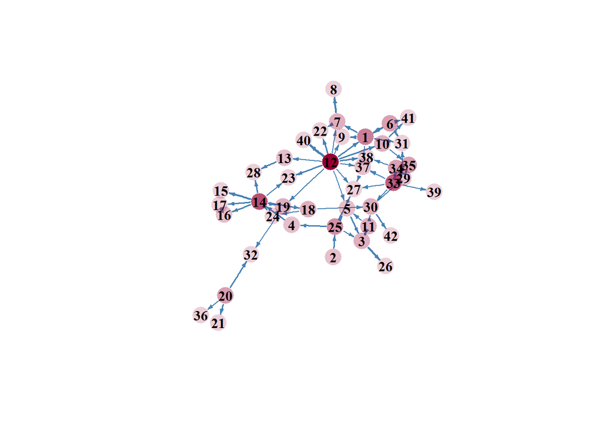

```r
#看看直接消耗系数取其他临界值的情况
fun=function(d,Weight){
  d1=d[(d$weight>Weight)&(d$p1!=d$p2),]
  g = graph.data.frame(d1, directed = T)
  deg= degree(g,mode = "out")+3 #根据顶点度大小生成调节参数
  weight=(d1$weight)^0.35*3
  set.seed("1234")
  plot(g, vertex.color= rgb(0.6,0,0.2,deg/max(deg)), vertex.frame.color = NA,
       vertex.label.color='black', vertex.label.font=2, edge.width=weight,
       edge.color='steelblue', edge.arrow.size=0.3)
}

fun(d,0.1)
```

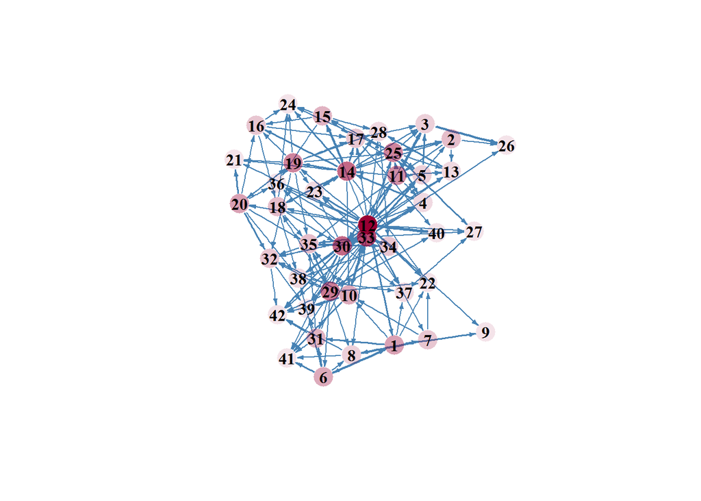

```r
fun(d,0.05)
```

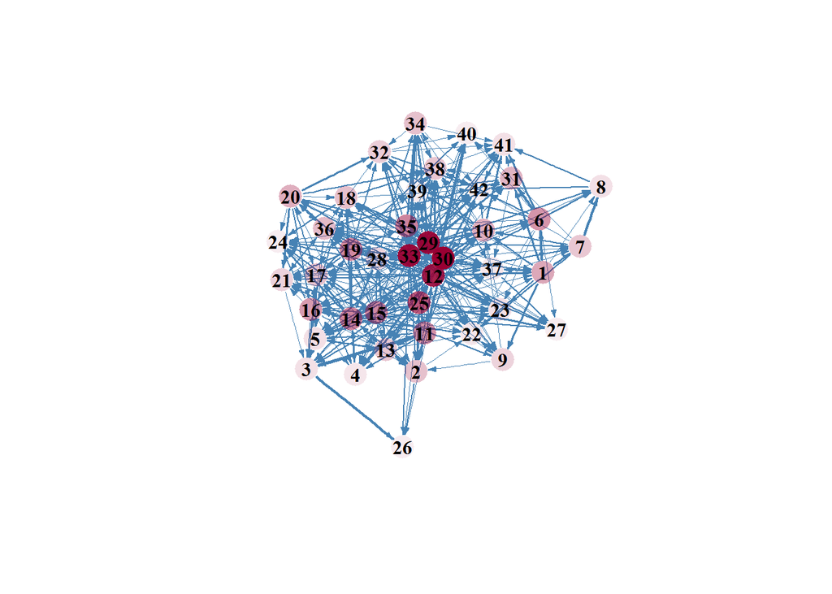

```r
fun(d,0.02)
```

# 2 中心度

## 2.1 中心度的概念

> 中心度研究能够识别网络中的重要节点，节点的重要程度由网络的拓扑属性、结构特点及节点在网络中的具体位置决定。MikeGotta指出“中心度的概念，简单来说是识别网络中具有高度连接的活动者”。这个定义有些片面，而维基百科中也没有给出明确的定义，给出的是“在图论和网络分析中，对一个节点的多种中心度测量，这些测量主要是决定图中一个节点的相对重要性。”的一种解释。  
> 之前的研究中并没有给出关于中心度的严格定义，本文认为它是关于节点重要性的度量指标。 这种重要性， 根据不同网络和结构特点及关系表现为节点的影响力、权威性（ 重要思想、 知识或判断决策的源头）、 流行度、控制力（如传输、流量的控制能力），便利性（位置上的优势、易于访问）或某种特殊意义，也可以表现为节点的脆弱性和易受攻击性。不同的中心度算法含义不同，此处给出的是一个总结性质的定义。

## 2.2 中心度的分类

- 节点中心度
- 紧密中心度
- 间距中心度

# 3 参考资料

[igraph包](http://xccds1977.blogspot.com/2012/06/igraph.html)

[R语言igraph包的使用](http://www.itdadao.com/articles/c15a287608p0.html)

[画网络关系图](http://www.85kf.com/news/2303.html)